# Sobol Assignment - EDS 230

#### c. Plot conductance estimates in a way that accounts for parameter uncertainty

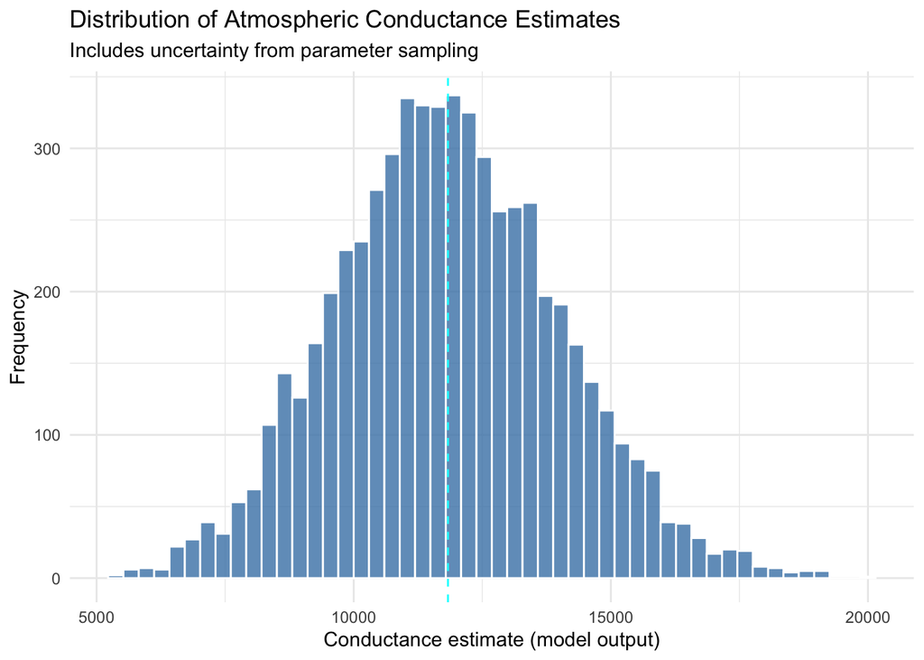

```r
# Combine parameter samples with model output
both <- cbind.data.frame(parameters, output = sens_Catm_Sobol$y)

# Plot distribution of conductance estimates, showing uncertainty from input parameters
ggplot(both, aes(x = output)) +
  geom_histogram(bins = 50, fill = "steelblue", color = "white", alpha = 0.8) +
  geom_vline(xintercept = mean(both$output), color = "cyan", linetype = "dashed") +
  labs(
    title = "Distribution of Atmospheric Conductance Estimates",
    subtitle = "Includes uncertainty from parameter sampling",
    x = "Conductance estimate (model output)",
    y = "Frequency"
  ) +
  theme_minimal()
```

#### d. Plot conductance estimates against windspeed use the parameter that is 2nd in terms of total effect on response

From the results of `sens_Catm_Sobol`, I have identified that vegetation height is 2nd in terms of total effect on response, followed by k_o and k_d.

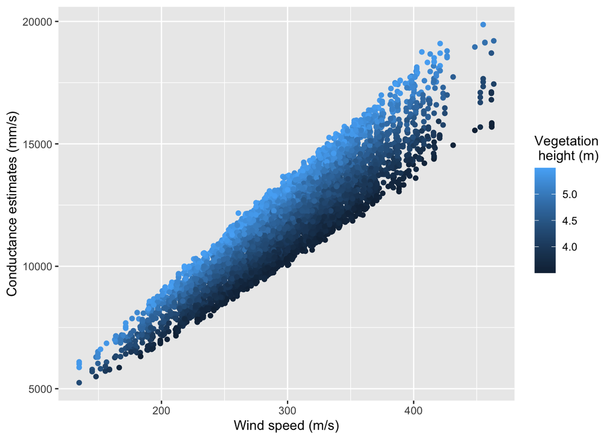

```r
# Plot conductance against wind speed colored by vegetation height
ggplot(both, aes(x=v, y=output, color = height)) +
  geom_point() +
  labs(x = "Wind speed (m/s)",
       y = "Conductance estimates (mm/s)",
       color = "Vegetation \n height (m)"
  )
```

#### e. Estimate the Sobol Indices for your output

```r
# View Sobol Indices that were estimated above
print(sens_Catm_Sobol)
```

[output not shown]

#### f. Comment on what this tells you about how atmospheric conductance

In the class example, we had lower and more consistent wind speeds, and taller vegetation. In that case, wind speed didn’t matter as much because it didn’t change much, and the tall vegetation reduced how much wind could affect the system. But in this case, small changes in wind speed cause much bigger changes in conductance. So, the model is much more sensitive to wind speed.